# An Introduction to the Twitter API and Sentiment Analysis

Robyn Ferg and Brian Kim

# rtweet

**Demonstration is adapted from rtweet documentation - https://github.com/mkearney/rtweet**

## Loading rtweet

First, run this code to install and load the library, rtweet.

NOTE: You will also need a Twitter account to run this code.

```r
#install.packages('rtweet')
library(rtweet)
```

## search_tweets

Firstly, we can use the Twitter search API to pull previously tweeted tweets - this function behaves the same as doing a search in the twitter search bar, returns a bunch of variables in a JSON format and then rtweet turns it into a dataframe for us.

In this example, we’re searching for tweets that include the hashtag #rstats, and limiting our results to 100 maximum. The include_rts argument indicates whether or not you want your results to include retweets. In this example we have set that to FALSE, so we would only get original tweets. Search_tweets using the standard Twitter API (the free version) will only pull historical tweets within the past week.

As you work through this notebook, if you run each cell in rapid succession you may hit a rate limit. You can only collect 18,000 tweets per 15 minutes. If I hit a rate limit I set a timer for 15 minutes and work on something else in the meantime. I’m going to limit many of these examples to 100 tweets each to avoid hitting rate limits.

```r
rstats = search_tweets("#rstats", n = 100, include_rts = FALSE)
```

Tweets from the last 6-9 days are collected, lets look at a 10.

```r
head(rstats$text, n=10)
```

```
##  [1] "The Real Python Podcast – Episode #98: Drawing Fractals With Python and Working With a Weather API #Analytics #DataScience #AI #ML #RStats #Python #coding #DataAnalytics https://t.co/Zn0v1EdDcO"
##  [2] "RStudio 1.2 Preview: The Little Things #Analytics #DataScience #AI #ML #RStats #Python #coding #DataAnalytics https://t.co/uqtL9Te9TK"
##  [3] "Socket Programming in Python (Guide) #Analytics #DataScience #AI #ML #RStats #Python #coding #DataAnalytics https://t.co/7IaMIyYARw"
##  [4] "Recruit Ponpare is Japan’s leading joint coupon site, offering huge discounts on everything from… #Analytics #DataScience #AI #ML #RStats #Python #coding #DataAnalytics https://t.co/vnoSnCiZ1T"
##  [5] "Announcing the 1st Shiny Contest #Analytics #DataScience #AI #ML #RStats #Python #coding #DataAnalytics https://t.co/vQWrRhj7wc"
##  [6] "Marcin Pionnier on finishing 5th in the RTA competition #Analytics #DataScience #AI #ML #RStats #Python #coding #DataAnalytics https://t.co/MCYoDUOh18"
##  [7] "Max Lin on finishing second in the R Challenge #Analytics #DataScience #AI #ML #RStats #Python #coding #DataAnalytics https://t.co/ToECkAPmNA"
##  [8] "Jeremy Howard on winning the Predict Grant Applications Competition #Analytics #DataScience #AI #ML #RStats #Python #coding #DataAnalytics https://t.co/jkINz5Q5RE"
##  [9] "Quan Sun on finishing in second place in Predict Grant Applications #Analytics #DataScience #AI #ML #RStats #Python #coding #DataAnalytics https://t.co/jQ7DK66R24"
## [10] "Yuanchen He on finishing third in the Melbourne University competition #Analytics #DataScience #AI #ML #RStats #Python #coding #DataAnalytics https://t.co/brBpRzjQqO"
```

In search_tweets we can use AND to find tweets that contain both #rstats AND the word data, in any position within the text. The space works as an AND search.

```r
rstats2 = search_tweets("#rstats data", n = 100, include_rts = FALSE)
```

Here we find tweets that contain both #rstats and also the word data.

```r
head(rstats2$text, n=10)
```

```
##  [1] "I no longer believe that an MS in Statistics is an appropriate route for becoming a Data Scientist. #Analytics #DataScience #AI #ML #RStats #Python #coding #DataAnalytics https://t.co/cd6pG5I91k"
##  [2] "Stop resampling data in classification problems. #Analytics #DataScience #AI #ML #RStats #Python #coding #DataAnalytics https://t.co/zWbRlzLiXk"
##  [3] "Lists to Data.Frames with imap #Analytics #DataScience #AI #ML #RStats #Python #coding #DataAnalytics https://t.co/YF1ZqnNej6"
##  [4] "Analyze data patterns to find fraudulent insurance claims #Analytics #DataScience #AI #ML #RStats #Python #coding #DataAnalytics https://t.co/dkT0IwM3V4"
##  [5] "Predict, manage, and monitor the call drops of cell towers using IBM Cloud Pak for Data #Analytics #DataScience #AI #ML #RStats #Python #coding #DataAnalytics https://t.co/LoJj3xi6YJ"
##  [6] "View data frame in r: use of View() function in R #Analytics #DataScience #AI #ML #RStats #Python #coding #DataAnalytics https://t.co/BcOw5ZprzI"
##  [7] "The Role of the Data Scientist #Analytics #DataScience #AI #ML #RStats #Python #coding #DataAnalytics https://t.co/mvW5pAB18n"
##  [8] "Data Science in Production: a Joint Event with Yotabites #Analytics #DataScience #AI #ML #RStats #Python #coding #DataAnalytics https://t.co/77nHgrcIkJ"
##  [9] "Score streaming data with a machine learning model #Analytics #DataScience #AI #ML #RStats #Python #coding #DataAnalytics https://t.co/nmKEsjgGsS"
## [10] "Best Data Science Books For Beginners #Analytics #DataScience #AI #ML #RStats #Python #coding #DataAnalytics https://t.co/8VuQ0IW4LK"
```

Let’s try an OR instead of an AND search. See the twitter search documentation for standard search operators: https://developer.twitter.com/en/docs/tweets/search/guides/standard-operators

```r
rstats3 = search_tweets("#rstats OR data", n = 100, include_rts = FALSE)
```

Here we find more variety of tweets as they contain either #rstats or the fairly common word “data.”

```r
head(rstats3$text, n=10)
```

```
##  [1] "When it says “raw data should not be used to assess vaccine effectiveness” on the COBR slides, what does it mean?"
##  [2] "@sirandson @WholeMarsBlog @mostlyharmlessz @TaylorOgan @DirtyTesla It's more than that. The only actual data we can get our hands on shows no improvement. If Tesla has data showing the opposite, don't you think they would provide it?"
##  [3] "The trove of data was leaked by an anonymous #whistleblower to a German newspaper. “I believe that #Swiss banking secrecy laws are immoral. The pretext of protecting financial privacy is merely a fig leaf covering the shameful role of Swiss banks as collaborators of #tax evaders” https://t.…
##  [4] "Buy your data https://t.co/Xqve8DRcfC"
##  [5] "Buy your data https://t.co/yiqhvmlVFu"
##  [6] "@JoshDubowAP Notes at bottom of list are using data from 2006-2021.  But ok, the author wants to cherry pick 2020."
##  [7] "Amo qnd minhas encomendas da shopee chegam antes da data prevista \U0001f929"
##  [8] "a unicap falando dia 14 e o professor falando que não tem data kkkkkkkkk"
##  [9] "@Nftlemonn @NFTQuin Dive into the tombs of the future, where the your minds data can be lost for ever.\n\nRetweet, like &amp; follow\U0001f4af\U0001f4cc\U0001f447\n#NFTGiveaway  #NFT #NFTdrop #NFTCommunity #NFT \nhttps://t.co/KkvqSgk9hB"
## [10] "@TFGmykL Dive into the tombs of the future, where the your minds data can be lost for ever.\n\nRetweet, like &amp; follow\U0001f4af\U0001f4cc\U0001f447\n#NFTGiveaway  #NFT #NFTdrop #NFTCommunity #NFT \nhttps://t.co/KkvqSgk9hB"
```

## Variables in Twitter Data

Tweets are collected from the API as JSON objects, but the rtweet package automatically converts each JSON into a vector and combines them into a dataframe.

The format of a JSON object looks like this:

`{"name":"John", "age":31, "city":"New York"}`

You receive a list of name:value pairs. This is obviously not a tweet JSON, those are rather large as they contain all of the variables listed below, with the corresponding items. There is one JSON object for each tweet collected.

```r
# LIST VARIABLE NAMES
colnames(rstats)
```

```
##  [1] "user_id"                 "status_id"
##  [3] "created_at"              "screen_name"
##  [5] "text"                    "source"
##  [7] "display_text_width"      "reply_to_status_id"
##  [9] "reply_to_user_id"        "reply_to_screen_name"
## [11] "is_quote"                "is_retweet"
## [13] "favorite_count"          "retweet_count"
## [15] "quote_count"             "reply_count"
## [17] "hashtags"                "symbols"
## [19] "urls_url"                "urls_t.co"
## [21] "urls_expanded_url"       "media_url"
## [23] "media_t.co"              "media_expanded_url"
## [25] "media_type"              "ext_media_url"
## [27] "ext_media_t.co"          "ext_media_expanded_url"
## [29] "ext_media_type"          "mentions_user_id"
```

[output cut: 30 more lines]

## What are retweets?

So far we’ve limited our tweets obtained in our searches to original tweets by utilizing the `include_rts = FALSE` arguement. What are retweets? Retweets are probably the most common type of tweet on twitter. Retweets are when users share the tweets of others on their own twitter timeline with attribution.

## Using Collected Tweet Data - Tweets over Time

We can make various plots using this saved data, for example, graphing the number of tweets by timeperiod.

```r
#install.packages('ggplot2')
library(ggplot2)
```

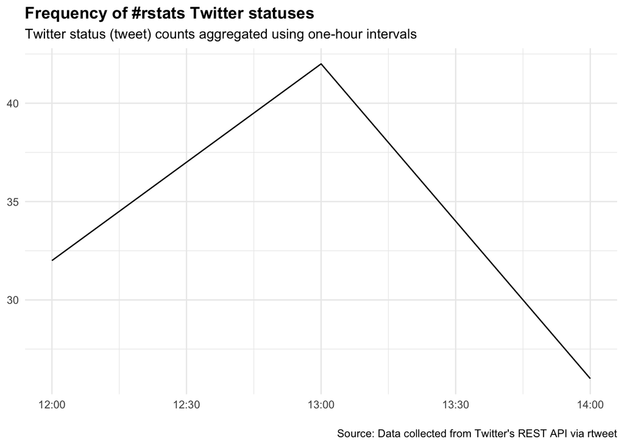

```r
ts_plot(rstats,"1 hours") +
  ggplot2::theme_minimal() +
  ggplot2::theme(plot.title = ggplot2::element_text(face = "bold")) +
  ggplot2::labs(
    x = NULL, y = NULL,
    title = "Frequency of #rstats Twitter statuses",
    subtitle = "Twitter status (tweet) counts aggregated using one-hour intervals",
    caption = "\nSource: Data collected from Twitter's REST API via rtweet"
  )
```

## Using Collected Twitter Data - Frequency Table

Or we can look at a frequency table of the “source” of the tweets - what application a user is using in order to send their tweets.

```r
#install.packages("plyr")
library(plyr)
```

```r
head(arrange(count(rstats, 'source'),desc(freq)))
```

|  | source | freq |
| --- | --- | --- |
| 1 | NadarSenpai | 45 |
| 2 | Twitter Web App | 25 |
| 3 | tidyverse_tweets | 7 |
| 4 | CRANberries Feed | 4 |
| 5 | Twitter for iPhone | 3 |
| 6 | Buffer | 2 |

## Using Collected Twitter Data - Mapping

To look at mapping tweets, we can collect only tweets that contain both the word “Michigan” and are in the English language.

```r
#install.packages("maps")
library(maps)
```

```r
## search for 10,000 tweets in English that contain the word "Michigan"
us = search_tweets("lang:en AND michigan", n = 1000)
```

Note that many tweets will not have geocodes/location information. Twitter first uses the geocode on the tweet, then if there is no geocode on the tweet itself, will use any location information from the user’s profile.

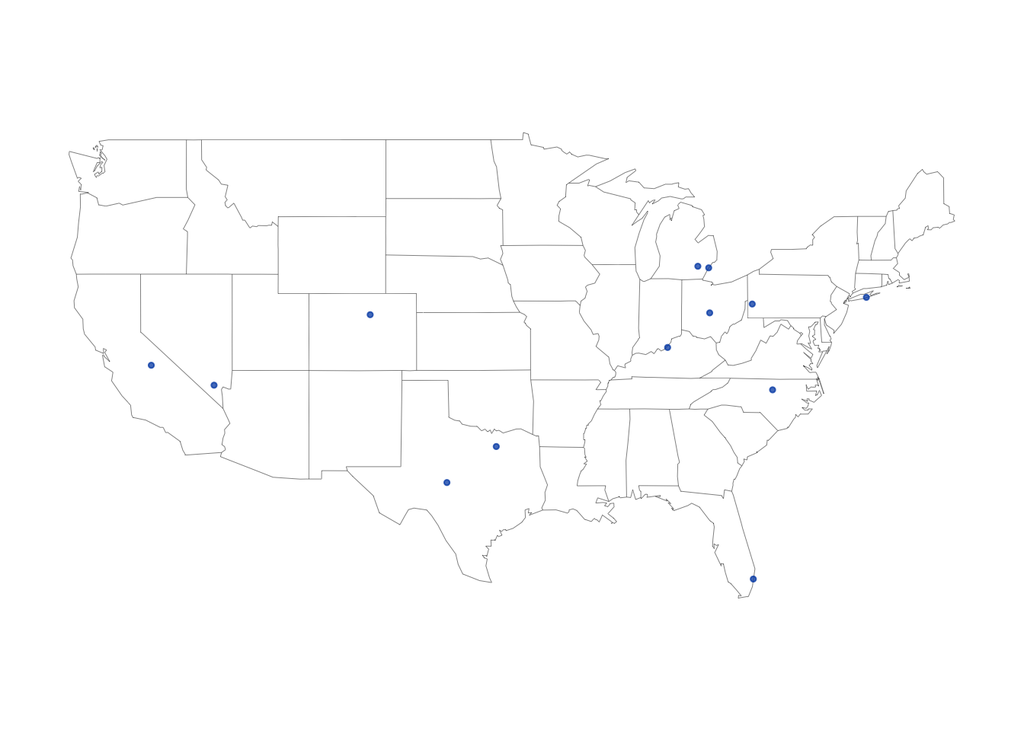

```r
## create lat/lng variables using all available tweet and profile geo-location data
us = lat_lng(us)

## plot state boundaries
par(mar = c(0, 0, 0, 0))
maps::map("state", lwd = .25)

## plot lat and lng points onto state map
points(us$lng, us$lat, pch = 20, cex = .75, col = rgb(0, .3, .7, .75))
```

# “Listening” to Twitter

## stream_tweets

So far we have done our analysis on past tweets through the search API. For most research applications you will want to “listen” to the twitter stream and obtain a 1% sample of all tweets as they are posted, 1) because you can monitor emerging situations and 2) because with a free account you are limited to searching the last 6-9 days, but you can stream continuously over a period of time to compile a corpus of tweets for analysis. You will likely obtain more tweets when streaming vs. searching, but streaming API doesn’t have as many operators to be used in keywords - search_tweets has options for NOT searches, types of media (containing an image or a periscope). You also cannot exclude retweets easily when streaming.

The most basic is obtaining a random sample, using no filters. We specify rtweet to listen for 10 seconds (The timeout argument is in seconds). rtweet will default to 30 seconds unless otherwise specified.

```r
library(rtweet)
st = stream_tweets(timeout=10, parse=TRUE)
```

## What do the tweets say?

```r
#PRINT TEXT OF LAST 10 TWEETS IN TABLE
tail(st$text, n=10)
```

```
##  [1] "Your girls are so cute @DiivesArt !\nBut Baozi is still one of the best for me! \U0001f60d https://t.co/MtdDdi1uVR"
##  [2] "\U0001f97a\U0001f97a\U0001f97a"
##  [3] "@sairamkaranam @LillyMogudu7 Pakkane ga, vachey Dallas ki"
##  [4] "https://t.co/BYsj3D5VVf"
##  [5] "アンソロ参加者が決まりましたのでお知らせです。\n参加者は主催含め11名で、以下のメンバーです\n(50音順・敬称略)(1/2)\nこん @konkoto_ss\nしづき @shi0410duki\n鉄パイプ @steelpipeJI\nとわ @tofleedama\n鳴宮仁 @jinnaruo\n\n(ツリーに続きます)"
##  [6] "@TheConWom The good news would be that there is scientific recognition of bio-fields as part of a universal communication that blends physical &amp; biological.\nBad news is insider intent to marketise &amp; weaponise any new discovery, setting pathological narrative as basis to 'save or im…
##  [7] "이재명 너무 하루에 두번씩 맞는 고장난 시계같아......\n어쨌든 고장난 시계니까 별로 갖고싶진 않은데 바로 옆에 쉴새없이 들락날락하면서 폭주하는 뻐꾸기시계있음"
##  [8] "https://t.co/5ajJrBsOxs"
##  [9] "@outnooooooooo\nご参加ありがとうございます！\n結果は…\n\n残念\U0001f622\n\nキャンペーンは2/27まで毎日参加可能！諦めずチャレンジしてね！\n\nさらにチャンス❣️\nInstagramでもキャンペーン開催中\U0001f389\nフォロー&amp;写真投稿で、ニトリ商品券2,000円分が当たる！\n詳細はこちらから\U0001f447\nhttps://t.co/SNui2HB5Wr https://t.co/rYtpkhtLG6"
## [10] "@chikx_ ♪(´ε｀ )"
```

Some of what you receive in the text might look like gibberish. These tweets may need to be cleaned before performing text analysis.

## Filtering the Stream

You can also listen for specific filter items (search terms).

With the debate over mask and vaccine requirements, we’ll list for tweets related to these topics. We will listen for one minute. The comma serves as an “OR” search. This search will listen for tweets that either contain both ‘vaccine’ and ‘mandate’ or contain both ‘mask’ and ‘mandate’ or contain ‘omicron’.

```r
vaccine_tweets = stream_tweets("vaccine mandate, mask mandate, omicron", timeout = 60)
```

## What do our tweets say?

```r
#PRINT TEXT OF FIRST 10 TWEETS IN TABLE
head(vaccine_tweets$text, n=10)
```

```
##  [1] "Früher sollten Lockdowns die Welle abflachen und verlängern, um eine Überlastung zu verhindern.\n\nPlötzlich sieht @Karl_Lauterbach es umgekehrt: Eine ÖFFNUNG würde die Welle verlängern! https://t.co/5jM07MHTWV"
##  [2] "Omicron has caused more deaths in the US than delta. \n\nA bad variant will look deceptively \"milder\" if you don't consider the confounders. We tried to warn. But sadly some people believed the erroneous assumption that it was mild."
##  [3] "https://t.co/KLinpgSNGG"
##  [4] "@oliverbeige Clearly they haven't seen this work:\n\nhttps://t.co/Mi30X9TBU3"
##  [5] "So we couldn’t defund the vaccine mandates because Burr, Inhofe, Romney and Graham couldn’t be bothered to show up.\n\nIs Lindsey Graham even back in this country from his trip to Israel?"
##  [6] "Mirip Lambang Nazi yang di Klaim Bentuk Virus Omicron Viral di Media Sosial, Ternyata Hoax\n\nhttps://t.co/JUGCLnt5SQ"
##  [7] "The reasoning is quite literally \"keep the mask mandate in place to symbolize that covid isn't over yet.\""
##  [8] "Numbers have looked great in NYC lately. It's good to hear an ER doc not known for downplaying Covid reporting the same good news on the ground."
##  [9] "Gli stronzi hanno visto che il picco dei contagi è stato superato, e quindi i guariti (la variante Omicron non è pericolosa).\nDopo 4 mesi dalla guarigione vorrebbero vaccinare di nuovo: siamo a febbraio, quindi a giugno.\nEcco perché \"prima dell'estate\"...\nhttps://t.co/IrbMrLHwyw"
## [10] "You cannot make this up. When the narrative collapses, they attempt to rescue it with another \"variant\". Anyway, they were just trying to save humanity and your grandmother."
```

Remember this is ~1% of all tweets about these topics in a one minute period.

FROM THE TWITTER API DOCUMENTATION: “A comma-separated list of phrases which will be used to determine what Tweets will be delivered on the stream. A phrase may be one or more terms separated by spaces, and a phrase will match if all of the terms in the phrase are present in the Tweet, regardless of order and ignoring case. By this model, you can think of commas as logical ORs, while spaces are equivalent to logical ANDs (e.g. ‘the twitter’ is the AND twitter, and ‘the,twitter’ is the OR twitter).” Standard stream parameters available at https://developer.twitter.com/en/docs/tweets/filter-realtime/guides/basic-stream-parameters.html. Scroll down to the section titled “track.”

Instead, let’s say we want to get tweets with just ‘vaccine’ AND ‘mandate’. This time we’ll save the tweets in raw JSON format inside your working directory. Afterwards we’ll parse the JSON file using a different function, parse_stream, to convert to a data frame.

```r
stream_tweets(
  "vaccine mandate",
  timeout = 60,
  parse=FALSE, # parse = FALSE to save as raw JSON
  file_name = "tweets"
)
```

```r
vaccine_mandate = parse_stream("tweets.json")
```

## What do our vaccine AND mandate tweets say?

Again a 1% sample of the universe of tweets in a short period.

```r
#PRINT TEXT OF FIRST 10 TWEETS
head(vaccine_mandate$text, n=10)
```

```
##  [1] "All of this...all of it...to preserve a useless vaccine mandate?"
##  [2] "@RudyHavenstein @cruisin4bruisin No one but me finds it odd that a group of truckers who were looking to protest about a mandatory vaccine mandate for the border crossing (which had a reciprocal US restriction)  ballooned into an attempt to overthrow their government and had funding from th…
##  [3] "The trucker protest isn’t even anti-vaccine. It’s anti-mandate. Most truckers are vaccinated and sit in a cab w no risk to anyone but themselves. Lots of countries like Denmark have no mandate and it’s fine. Portraying this anti-mandate protest as dangerous fascism is absurd."
##  [4] "In yet another stunning success story for mask mandates and vaccine passports, cases in New Zealand are up nearly 24,000% since the mask mandate in August and they’re now reporting more new population adjusted cases each day than the US\n\nWorking perfectly, as always https://t.co/kOaPhM5OZ…
##  [5] "Covid live: New Zealand to end vaccine mandates after Omicron peak https://t.co/1rrxMGhSBi"
##  [6] "I shouldn’t have to explain this but protesting a vaccine mandate is not even remotely similar, and certainly not as heroic, as resisting Nazis or fighting against racism. Where are your critical thinking skills?"
##  [7] "All of this...all of it...to preserve a useless vaccine mandate?"
##  [8] "I wonder what is in the contract between Trudeau and Pfizer that is so secret. Did Pfizer make policy demands, like vaccine mandates, that Trudeau agreed to obey? Why else are the contracts secret and why else would Trudeau be so extremist and undemocratic?"
##  [9] "All of this...all of it...to preserve a useless vaccine mandate?"
## [10] "Tomorrow night at 19:30 we are discussing the ongoing consultation to reverse the vaccine mandate for #SocialCare\n\nWhat does this mean for #homecare?\nWhat about #carehomes?\nAre there any legal implications?\n\n@NectarHR @drjanetownson @Agincare\n \nJoin here https://t.co/7DVNt0O0zo http…
```

Note 2 things - 1) The search terms could be contained in quoted tweet not necessarily in the message added by the user who quoted or retweeted, 2) some of the tweets appear to be truncated. Only RTs or tweets with embedded quoted tweets should be truncated, and the quoted tweets or tweets that are being retweeted are included in the variables quoted_text and retweet_text, so all text is included.

```r
print("TWEET TEXT")
```

```
## [1] "TWEET TEXT"
```

```r
head(vaccine_mandate$text, n=5)
```

```
## [1] "All of this...all of it...to preserve a useless vaccine mandate?"
## [2] "@RudyHavenstein @cruisin4bruisin No one but me finds it odd that a group of truckers who were looking to protest about a mandatory vaccine mandate for the border crossing (which had a reciprocal US restriction)  ballooned into an attempt to overthrow their government and had funding from the…
## [3] "The trucker protest isn’t even anti-vaccine. It’s anti-mandate. Most truckers are vaccinated and sit in a cab w no risk to anyone but themselves. Lots of countries like Denmark have no mandate and it’s fine. Portraying this anti-mandate protest as dangerous fascism is absurd."
## [4] "In yet another stunning success story for mask mandates and vaccine passports, cases in New Zealand are up nearly 24,000% since the mask mandate in August and they’re now reporting more new population adjusted cases each day than the US\n\nWorking perfectly, as always https://t.co/kOaPhM5OZ8…
## [5] "Covid live: New Zealand to end vaccine mandates after Omicron peak https://t.co/1rrxMGhSBi"
```

```r
print("RETWEET TEXT")
```

```
## [1] "RETWEET TEXT"
```

```r
head(vaccine_mandate$retweet_text, n=5)
```

```
## [1] "All of this...all of it...to preserve a useless vaccine mandate?"
## [2] NA
## [3] "The trucker protest isn’t even anti-vaccine. It’s anti-mandate. Most truckers are vaccinated and sit in a cab w no risk to anyone but themselves. Lots of countries like Denmark have no mandate and it’s fine. Portraying this anti-mandate protest as dangerous fascism is absurd."
## [4] "In yet another stunning success story for mask mandates and vaccine passports, cases in New Zealand are up nearly 24,000% since the mask mandate in August and they’re now reporting more new population adjusted cases each day than the US\n\nWorking perfectly, as always https://t.co/kOaPhM5OZ8…
## [5] "Covid live: New Zealand to end vaccine mandates after Omicron peak https://t.co/1rrxMGhSBi"
```

```r
print("QUOTE TWEET TEXT")
```

```
## [1] "QUOTE TWEET TEXT"
```

```r
head(vaccine_mandate$quoted_text, n=5)
```

```
## [1] NA NA NA NA NA
```

## Listening Over Time

Here is example code for the listening you will be doing for your project. In the “q” variable you will list your keywords for your searches, using spaces for AND and commas for OR.

IMPORTANT: If you’re going to leave your computer on to run this over time, make sure to set your power and sleep settings so that the PC will not go to sleep. If it does, your code will stop and you will lose data and have to restart it.

```r
## Stream keywords used to filter tweets
q = "vaccine mandate, mask mandate, omicron, vaccine trust, vaccine cdc, breakthrough infection"
## Put your selected filter terms here ^^^^,separated by commas.
## The commas serve as an OR search. Spaces, as in "vaccine trust" serve as an AND search
## where both items need to appear in the same tweet, but not necessarily next to each other.

## Stream time in seconds so for one minute set timeout = 60
## For larger chunks of time, I recommend multiplying 60 by the number
## of desired minutes. This method scales up to hours as well
## (x * 60 = x mins, x * 60 * 60 = x hours)

# timeout =  60 * 60 * 24  # timeout for one day
timeout = 120 # timeout for 2 minutes

## Monitor your progress, you may have to restart your code if the internet blips or
## if your computer restarts.  By not parsing and saving the raw JSON, you should hopefully not lose any data.

stream_tweets(
  q,
  parse = FALSE,
  timeout = timeout,
  file_name = "tweets1")
stream_tweets(
  q,
  parse = FALSE,
  timeout = timeout,
  file_name = "tweets2")
```

##Parsing JSONS and appending dataframes

```r
## Parse from json file to get a usable dataframe
tweets1 = parse_stream("tweets1.json") #replace tweets1 with the name of the json file
tweets2 = parse_stream("tweets2.json") #check your folder and see how many stream files you have, parse each into a separate dataframe, then bind using the code below, adding each df name to the rbind function
all_tweets = rbind(tweets1, tweets2)
```

## Monitor Your Output

You may want to use a series of shorter listening times (such as 1 day) and at the end of each day inspect the tweets you’ve received for trends so that you can add any emerging hashtags to your filter terms.

## Very Basic Text Mining - Bag of Words

To see what popular terms are in your collected tweets, we’ll use a text mining package, qdap, to look at frequent terms. For this example I’m using the vaccine tweets from earlier. Qdap will require you to have Java installed on your computer matching (32-bit vs. 64-bit) your version of R. If you get an error when loading qdap, get the right version of Java at https://www.java.com/en/download/manual.jsp.

```r
#install.packages('qdap')
library(qdap)
library(tidyverse)
```

## The Bag of Vaccine Words

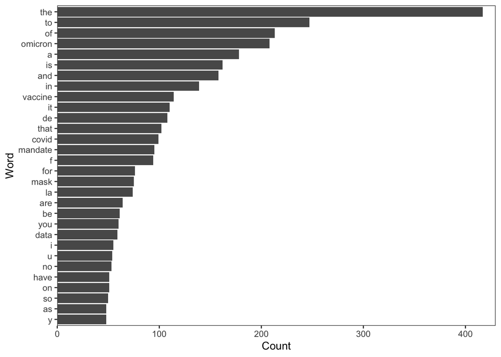

```r
frequent_terms = freq_terms(all_tweets["text"], 30)
plot(frequent_terms)
```

Some of the words are expected (e.g., covid), we streamed for tweets about the new vaccines. Note that this is counting the number of times these words appear, not the number of tweets in which these words appear. If “covid” is in one tweet 3 times, it adds 3 instances of “covid” to the totals reflected above.

We also get words that don’t mean much to us, like the, to, a, etc. These are typically called stopwords. Let’s remove these.

```r
bagVaccines = all_tweets$text %>% iconv("latin1", "ASCII", sub="") %>% scrubber() %sw% qdapDictionaries::Top200Words
```

And now look at the frequent terms again.

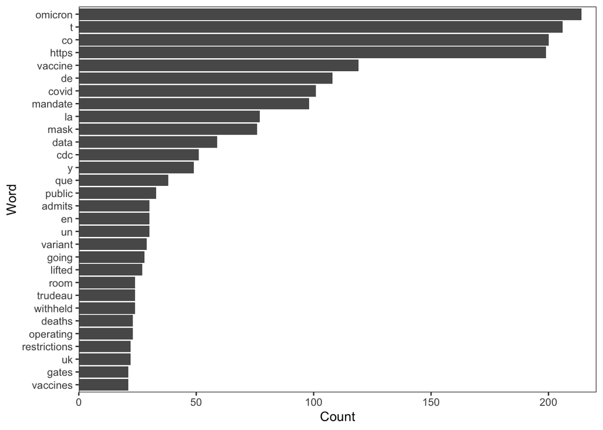

```r
frequent_terms = freq_terms(bagVaccines, 30)
plot(frequent_terms)
```

With the recent protests in Canada, it might be an interesting case study. To further analyze those tweets, I could create a dataframe that just includes tweets with the word “canada”.

```r
vaccines_ottawa = all_tweets%>%filter(str_detect(str_to_lower(text), "canada") == TRUE)
head(vaccines_ottawa$text, n=10)
```

```
## [1] "Ivermectin\n\nHow many lives could have been saved?\n\n#TrudeauTyranny #CanadaHasFallen  #Gestapo Rebel News #covid #omicron #NoVaccineMandates #NoMoreLockdowns #DoNotComply #blackfacehitler #freedomconvoy22 #TrudeauDictatorshipMustGo \n\nhttps://t.co/m0fZQhlx1j"
## [2] "@_thenewclassiic los de canada q eran en febrero se pospusieron para despues por el omicron"
```

# Sentiment Analysis

Now that we have our corpus of tweets from the Twitter API, we can perform a sentiment analysis. We will focus on the `all_tweets’ dataset from above.

## Filtering Out Irrelevant Tweets

There will often be tweets that are not relevant to the analysis at hand. For example, the tweet “hello @pfizer can you add serotonin into the vaccine please we all need it” is more of a joke rather than trust in the vaccine, so we might want to remove these tweets from the analysis.

```r
#install.packages('quanteda')
library(quanteda)

irrelevantWords = c('serotonin')

newTweets = data.frame()
irrelevantTweets = data.frame()

for(i in 1:nrow(all_tweets)){
  # break up tweet into individual words
  tweet = all_tweets$text[i]
  tweet = tolower(tweet)
  words = tokens(tweet)
  # if it contains an irrelevant word, put it in the irrelevant data frame
  if(length(intersect(words[['text1']], irrelevantWords))>0){
    irrelevantTweets = rbind(irrelevantTweets, all_tweets[i,])
  }
  else{
    newTweets = rbind(newTweets, all_tweets[i,])
  }
}
```

## Sentiment Calculation

We will use various methods to calculate the sentiment of tweets. The first four are dictionary-based methods, with the dictionaries being included in the ‘SentimentAnalysis’ package.

```r
# install.packages('SentimentAnalysis')
library(SentimentAnalysis)
```

The four dictionaries are: GI– Harvard-IV General Inquirer dictionary HE– Henry’s finance specific dictionary LM– Loughran-McDonald financial dictionary QDAP

More detail on this package can be found at: https://cran.r-project.org/web/packages/SentimentAnalysis/SentimentAnalysis.pdf

To see the words in one of these packages:

```r
data('DictionaryGI')
DictionaryGI$positive[1:100]
```

```
##   [1] "abide"           "ability"         "able"            "abound"
##   [5] "absolve"         "absorbent"       "absorption"      "abundance"
##   [9] "abundant"        "accede"          "accentuate"      "accept"
##  [13] "acceptable"      "acceptance"      "accessible"      "accession"
##  [17] "acclaim"         "acclamation"     "accolade"        "accommodate"
##  [21] "accommodation"   "accompaniment"   "accomplish"      "accomplishment"
##  [25] "accord"          "accordance"      "accountable"     "accrue"
##  [29] "accuracy"        "accurate"        "accurateness"    "achieve"
##  [33] "achievement"     "acknowledgement" "acquaint"        "acquaintance"
##  [37] "acquit"          "acquittal"       "actual"          "actuality"
##  [41] "adamant"         "adaptability"    "adaptable"       "adaptation"
##  [45] "adaptive"        "adept"           "adeptness"       "adequate"
##  [49] "adherence"       "adherent"        "adhesion"        "adhesive"
##  [53] "adjunct"         "adjust"          "adjustable"      "adjustment"
##  [57] "admirable"       "admiration"      "admire"          "admirer"
##  [61] "admit"           "admittance"      "adorable"        "adore"
##  [65] "adorn"           "adornment"       "adroit"          "adroitly"
##  [69] "adulation"       "adult"           "advance"         "advancement"
##  [73] "advantage"       "advantageous"    "advent"          "adventuresome"
##  [77] "adventurous"     "advisable"       "advocacy"        "affability"
##  [81] "affable"         "affection"       "affectionate"    "affiliate"
##  [85] "affiliation"     "affinity"        "affirm"          "affirmation"
##  [89] "affirmative"     "affix"           "affluence"       "affluent"
##  [93] "afloat"          "aggregate"       "aggregation"     "agile"
##  [97] "agility"         "agreeable"       "agreement"       "aid"
```

```r
DictionaryGI$negative[1:100]
```

```
##   [1] "abandon"        "abandonment"    "abate"          "abdicate"
##   [5] "abhor"          "abject"         "abnormal"       "abolish"
##   [9] "abominable"     "abrasive"       "abrupt"         "abscond"
##  [13] "absence"        "absent"         "absent-minded"  "absentee"
##  [17] "absurd"         "absurdity"      "abuse"          "abyss"
##  [21] "accident"       "accost"         "accursed"       "accusation"
##  [25] "accuse"         "ache"           "acrimonious"    "acrimony"
##  [29] "addict"         "addiction"      "admonish"       "admonition"
##  [33] "adulterate"     "adulteration"   "adultery"       "adversary"
##  [37] "adverse"        "adversity"      "affectation"    "afflict"
##  [41] "affliction"     "afraid"         "against"        "aggravate"
##  [45] "aggravation"    "aggression"     "aggressive"     "aggressiveness"
##  [49] "aggressor"      "aggrieve"       "aghast"         "agitate"
##  [53] "agitation"      "agitator"       "agonize"        "agony"
##  [57] "ail"            "ailment"        "aimless"        "alarm"
##  [61] "alarming"       "alas"           "alibi"          "alien"
##  [65] "alienate"       "alienation"     "allegation"     "allege"
##  [69] "aloof"          "altercation"    "ambiguity"      "ambiguous"
##  [73] "ambivalent"     "ambush"         "amiss"          "amputate"
##  [77] "anarchist"      "anarchy"        "anger"          "angry"
##  [81] "anguish"        "animosity"      "annihilate"     "annihilation"
##  [85] "annoy"          "annoyance"      "anomalous"      "anomaly"
##  [89] "antagonism"     "antagonist"     "antagonistic"   "antagonize"
##  [93] "anti-social"    "antipathy"      "antiquated"     "antitrust"
##  [97] "anxiety"        "anxious"        "anxiousness"    "apathetic"
```

The fifth dictionary is Lexicoder, which consists of word lists for positive, negative, negated positive, and negated negative words.

```r
data_dictionary_LSD2015$negative[1:100]
```

```
##   [1] "a lie"            "abandon*"         "abas*"
##   [4] "abattoir*"        "abdicat*"         "aberra*"
##   [7] "abhor*"           "abject*"          "abnormal*"
##  [10] "abolish*"         "abominab*"        "abominat*"
##  [13] "abrasiv*"         "absent*"          "abstrus*"
##  [16] "absurd*"          "abus*"            "accident*"
##  [19] "accost*"          "accursed*"        "accusation*"
##  [22] "accuse*"          "accusing*"        "acerbi*"
##  [25] "ache*"            "aching*"          "achy"
##  [28] "acomia*"          "acrimon*"         "adactylism*"
##  [31] "addict*"          "admonish*"        "admonition*"
##  [34] "adulterat*"       "adultery*"        "advers*"
##  [37] "affectation*"     "affected*"        "affected manner*"
##  [40] "afflict*"         "affright*"        "affront*"
##  [43] "afraid*"          "against"          "ageism"
```

[output cut: 19 more lines]

```r
data_dictionary_LSD2015$positive[1:100]
```

```
##   [1] "ability*"     "abound*"      "absolv*"      "absorbent*"   "absorption*"
##   [6] "abundanc*"    "abundant*"    "acced*"       "accentuat*"   "accept*"
##  [11] "accessib*"    "acclaim*"     "acclamation*" "accolad*"     "accommodat*"
##  [16] "accomplish*"  "accord"       "accordan*"    "accorded*"    "accords"
##  [21] "accountab*"   "accru*"       "accuracy*"    "accurat*"     "accustom*"
##  [26] "ace"          "aced"         "aces"         "achiev*"      "acquaintanc*"
##  [31] "acquiesc*"    "active*"      "actual"       "actuali*"     "adaptab*"
##  [36] "adaptive"     "adept*"       "adequat*"     "adhere*"      "admirab*"
##  [41] "admiration*"  "admire*"      "admiring*"    "admit*"       "adopt*"
##  [46] "adorable"     "adorably"     "adoration"    "adore*"       "adoring"
##  [51] "adorn*"       "adornment"    "adroit*"      "advanc*"      "advantag*"
##  [56] "adventur*"    "advisab*"     "advocacy*"    "advocat*"     "affab*"
##  [61] "affability*"  "affection*"   "affinity*"    "affirm*"      "affix*"
##  [66] "affluent*"    "afford*"      "afloat*"      "agil*"        "agree*"
##  [71] "aid"          "aided"        "aids"         "alertness"    "aliv*"
##  [76] "allay*"       "allegian*"    "alleviat*"    "allianc*"     "allied*"
##  [81] "allowab*"     "allowed*"     "allur*"       "ally*"        "alright"
##  [86] "amatory*"     "amaz*"        "ameliorat*"   "amenab*"      "amends"
##  [91] "amiab*"       "amicab*"      "amnesty*"     "amore"        "amorous*"
##  [96] "amour*"       "ampl*"        "amus*"        "angel"        "angelic*"
```

```r
data_dictionary_LSD2015$neg_positive[1:100]
```

```
##   [1] "best not"         "better not"       "no damag*"
##   [4] "no no"            "not ability*"     "not able"
##   [7] "not abound*"      "not absolv*"      "not absorbent*"
##  [10] "not absorption*"  "not abundanc*"    "not abundant*"
##  [13] "not acced*"       "not accentuat*"   "not accept*"
##  [16] "not accessib*"    "not acclaim*"     "not acclamation*"
##  [19] "not accolad*"     "not accommodat*"  "not accomplish*"
##  [22] "not accord"       "not accordan*"    "not accorded*"
##  [25] "not accords"      "not accountab*"   "not accru*"
##  [28] "not accuracy*"    "not accurat*"     "not accustom*"
##  [31] "not ace"          "not aced"         "not aces"
##  [34] "not achiev*"      "not acquaintanc*" "not acquiesc*"
##  [37] "not active*"      "not actual"       "not actuali*"
##  [40] "not adaptab*"     "not adaptive"     "not adept*"
##  [43] "not adequat*"     "not adhere*"      "not admirab*"
```

[output cut: 19 more lines]

```r
data_dictionary_LSD2015$neg_negative[1:100]
```

```
##   [1] "not a lie"            "not abandon*"         "not abas*"
##   [4] "not abattoir*"        "not abdicat*"         "not aberra*"
##   [7] "not abhor*"           "not abject*"          "not abnormal*"
##  [10] "not abolish*"         "not abominab*"        "not abominat*"
##  [13] "not abrasiv*"         "not absent*"          "not abstrus*"
##  [16] "not absurd*"          "not abus*"            "not accident*"
##  [19] "not accost*"          "not accursed*"        "not accusation*"
##  [22] "not accuse*"          "not accusing*"        "not acerbi*"
##  [25] "not ache*"            "not aching*"          "not achy"
##  [28] "not acomia*"          "not acrimon*"         "not adactylism*"
##  [31] "not addict*"          "not admonish*"        "not admonition*"
##  [34] "not adulterat*"       "not adultery*"        "not advers*"
##  [37] "not affectation*"     "not affected*"        "not affected manner*"
##  [40] "not afflict*"         "not affright*"        "not affront*"
##  [43] "not afraid*"          "not against"          "not ageism"
```

[output cut: 19 more lines]

To calculate sentiment of each tweet using the ‘SentimentAnalysis’ package:

```r
sentiments = analyzeSentiment(iconv(as.character(newTweets$text), to='UTF-8'))
head(sentiments)
```

|  | WordCount | SentimentGI | NegativityGI | PositivityGI | SentimentHE | NegativityHE | PositivityHE | SentimentLM | NegativityLM | PositivityLM | RatioUncertaintyLM | SentimentQDAP | NegativityQDAP | PositivityQDAP |
| --- | --- | --- | --- | --- | --- | --- | --- | --- | --- | --- | --- | --- | --- | --- |
| 1 | 3 | 0.00000000 | 0.00000000 | 0.00000000 | 0.00000000 | 0.000 | 0.00000000 | 0.00000000 | 0.00000000 | 0.00000000 | 0 | 0.00000000 | 0.00000000 | 0.00000000 |
| 2 | 19 | 0.00000000 | 0.10526316 | 0.10526316 | 0.05263158 | 0.000 | 0.05263158 | 0.00000000 | 0.05263158 | 0.05263158 | 0 | -0.05263158 | 0.15789474 | 0.10526316 |
| 3 | 15 | 0.13333333 | 0.20000000 | 0.33333333 | 0.00000000 | 0.000 | 0.00000000 | 0.00000000 | 0.00000000 | 0.00000000 | 0 | 0.20000000 | 0.06666667 | 0.26666667 |
| 4 | 22 | 0.04545455 | 0.00000000 | 0.04545455 | 0.00000000 | 0.000 | 0.00000000 | 0.00000000 | 0.00000000 | 0.00000000 | 0 | 0.00000000 | 0.04545455 | 0.04545455 |
| 5 | 8 | -0.25000000 | 0.37500000 | 0.12500000 | -0.12500000 | 0.125 | 0.00000000 | -0.25000000 | 0.25000000 | 0.00000000 | 0 | -0.25000000 | 0.25000000 | 0.00000000 |
| 6 | 23 | 0.00000000 | 0.04347826 | 0.04347826 | 0.00000000 | 0.000 | 0.00000000 | 0.04347826 | 0.00000000 | 0.04347826 | 0 | 0.00000000 | 0.04347826 | 0.04347826 |

The variables are: WordCount = number of non-stopwords in the tweet NegativityGI = number of negative words in the tweet that are in the GI negative dictionary / WordCount PositivityGI = number of negative words in the tweet that are in the GI positive dictionary / WordCount SentimentGI = PositivityGI - NegativityGI = (# positive words - # negative words) / WordCount

HE, LM, QDAP are similar

When using Lexicoder, we calculate number of positive words = positive words - negated positive + negated negative number of negative words = negative words - negated negative + negated positive

```r
tokenized=quanteda::tokens_lookup(quanteda::tokens(newTweets$text), dictionary=data_dictionary_LSD2015, exclusive=FALSE)
sentiments$LCpos = sapply(tokenized, function(x) sum(x=='POSITIVE') - sum(x=='NEG_POSITIVE') + sum(x=='NEG_NEGATIVE'))
sentiments$LCneg = sapply(tokenized, function(x) sum(x=='NEGATIVE') - sum(x=='NEG_NEGATIVE') + sum(x=='NEG_POSITIVE'))
sentiments$LC = (sentiments$LCpos-sentiments$LCneg)/sentiments$WordCount
```

The next sentiment method we consider is a rule-based sentiment analysis tool called Vader. Vader takes all of the lexical and grammatical features of the tweet and returns a continuous sentiment score between -1 (very negative) to 1 (very positive).

```r
#install.packages('vader')
library(vader)
vader_scores = vader_df(newTweets$text)
sentiments$Vader = vader_scores$compound
```

To see how the dictionaries compare to each other:

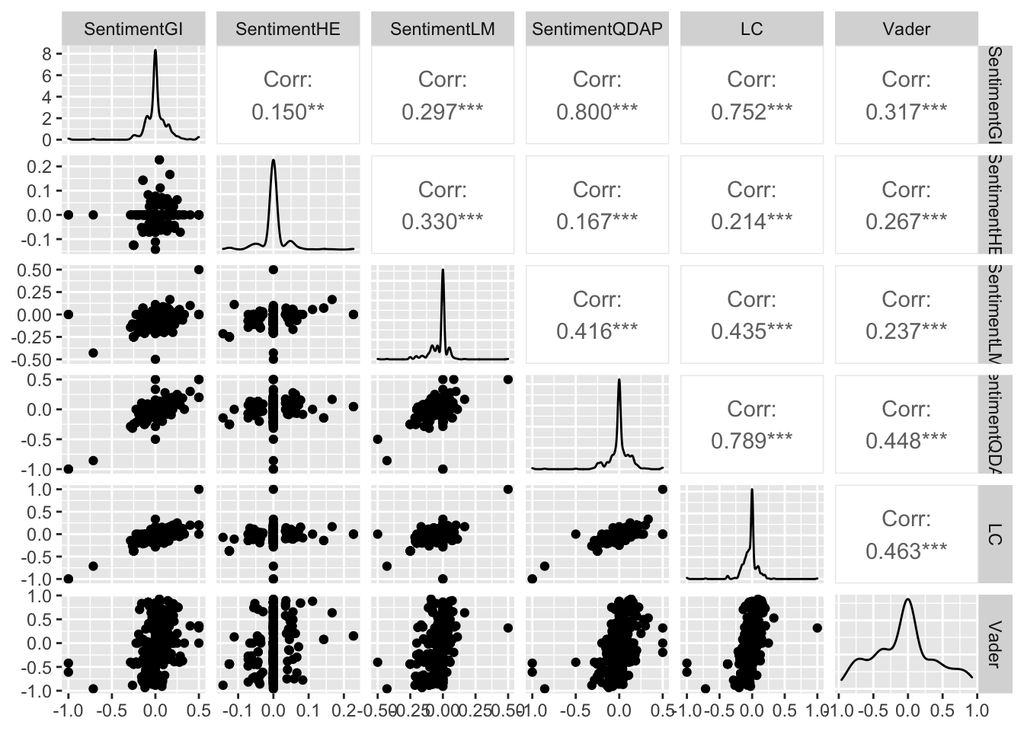

```r
#install.packages('GGally')
library(GGally)
with(sentiments, ggpairs(data.frame(SentimentGI, SentimentHE, SentimentLM,
                                    SentimentQDAP, LC, Vader)))
```

## Sentiment Change Over Time

On the graph below, the x-axis is the time and date the tweet was sent, and the y-axis is the sentiment of the tweet. Since the tweets used were gathered in the time span of a few minutes, we don’t expect to see any meaningful change in sentiment over time. Sentiment of tweets captured over days may tell a different story, especially if any good or bad news about the vaccine came out during that timeframe.

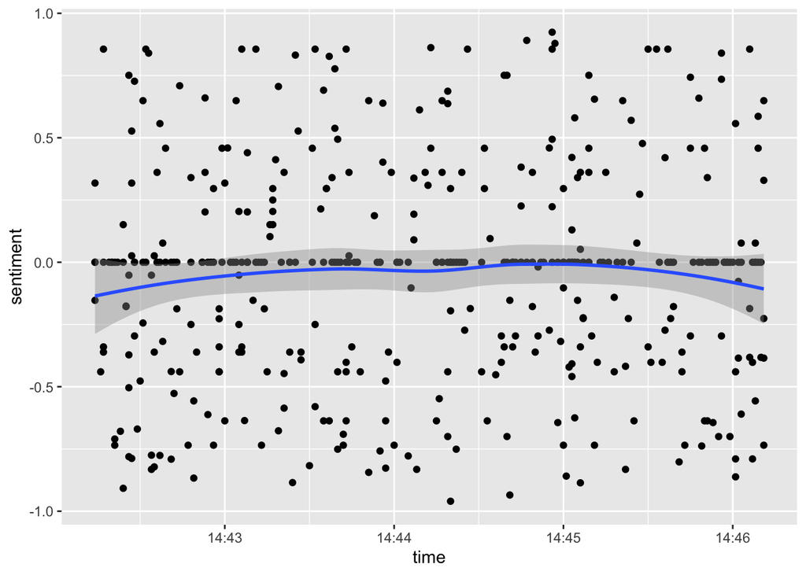

```r
ggplot(data=data.frame(time=newTweets$created_at, sentiment=sentiments$Vader), aes(x=time, y=sentiment)) + geom_point() + geom_smooth()
```

## Sentiment of retweets vs. original tweets

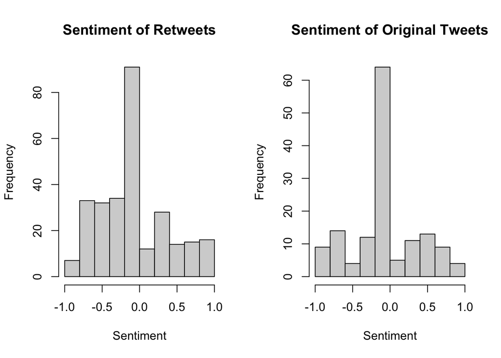

```r
par(mfrow=c(1,2))
hist(sentiments$Vader[newTweets$is_retweet==TRUE], main='Sentiment of Retweets', xlab='Sentiment')
hist(sentiments$Vader[newTweets$is_retweet==FALSE], main='Sentiment of Original Tweets', xlab='Sentiment')
```

```r
par(mfrow=c(1,1))
```

```r
mean(sentiments$Vader[newTweets$is_retweet==TRUE], na.rm=TRUE)
```

```
## [1] -0.05571986
```

```r
mean(sentiments$Vader[newTweets$is_retweet==FALSE], na.rm=TRUE)
```

```
## [1] -0.03088276
```

## Are longer tweets more positive or negative?

In the plot below, the shade of the point refers to how many tweets are at that location.

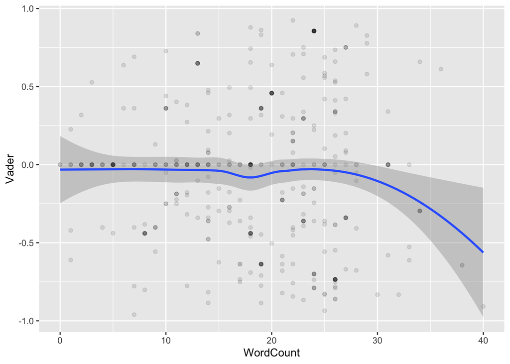

```r
ggplot(sentiments, aes(x=WordCount, y=Vader)) + geom_point(alpha=.1) + geom_smooth()
```